# Introduction to RNAseq Methods

July 2020

## HTS Applications - Overview

**DNA Sequencing**

- Genome Assembly
- SNPs/SVs/CNVs
- DNA methylation
- DNA-protein interactions (ChIPseq)
- Chromatin Modification (ATAC-seq/ChIPseq)

[**RNA Sequencing**](https://emea.illumina.com/content/dam/illumina-marketing/documents/applications/ngs-library-prep/for-all-you-seq-rna.pdf)

- Transcriptome Assembly
- **Differential Gene Expression**
- Fusion Genes
- Splice variants

**Single-Cell**

- RNA/DNA
- Low-level RNA/DNA detection
- Cell-type classification
- Dissection of heterogenous cell populations

## RNAseq Workflow

**Library Preparation**

**Sequencing**

**Bioinformatics Analysis**

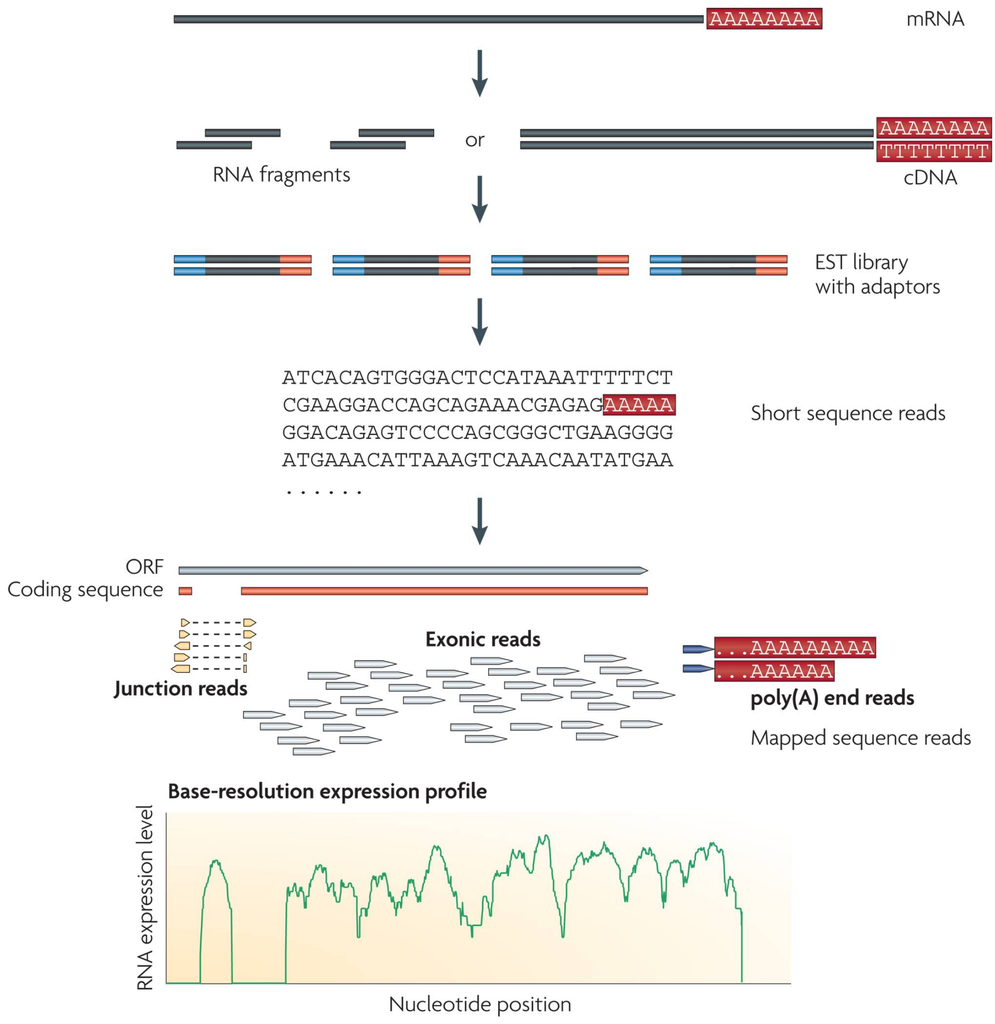

Image adapted from: Wang, Z., et al. (2009), Nature Reviews Genetics, 10, 57–63.

## Coverage: How many reads do we need?

The coverage is defined as:

\(\frac{Read\,Length\;\times\;Number\,of\,Reads}{Length\,of\,Target\,Sequence}\)

The amount of sequencing needed for a given sample is determined by the goals of the experiment and the nature of the RNA sample.

- For a general view of differential expression: 5–25 million reads per sample
- For alternative splicing and lowly expressed genes: 30–60 million reads per sample.
- In-depth view of the transcriptome/assemble new transcripts: 100–200 million reads
- Targeted RNA expression requires fewer reads.
- miRNA-Seq or Small RNA Analysis require even fewer reads.

## Read length

### Long or short reads? Paired or Single end?

The answer depends on the experiment:

- Gene expression – a short single read, e.g. SE 50, is sufficient.
- kmer-based quantification of Gene Expression (Salmon etc.) - benefits from PE.
- Transcriptome Analysis – longer paired-end reads (such as 2 x 75 bp).
- Small RNA Analysis – short single read, e.g. SE50 - will need trimming.

## Sources of Noise

[figure not shown]

## Sources of Noise - Sampling Bias

[figure not shown]

## Sources of Noise - Transcript Length

[figure not shown]

The length of the transcript affects the number of RNA fragments present in the library from that gene.

## Sources of Noise - Sequencing Artefacts

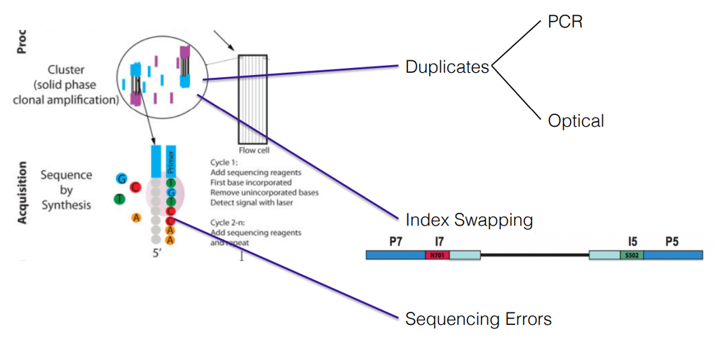

## Capturing Variance - Replication

### Biological Replication

- Measures the biological variations between individuals
- Accounts for sampling bias

### Technical Replication

- Measures the variation in response quantification due to imprecision in the technique
- Accounts for technical noise

## Capturing Variance - Replication

### Biological Replication

Each replicate is from an indepent biological individual

- *In Vivo*:
  - Patients
  - Mice
- *In Vitro*:
  - Different cell lines
  - Different passages

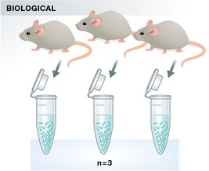

## Capturing Variance - Replication

### Technical Replication

Replicates are from the same individual but processed separately

- Experimental protocol
- Measurement platform

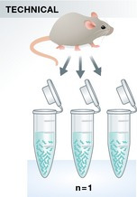

## More Depth or More Reps?

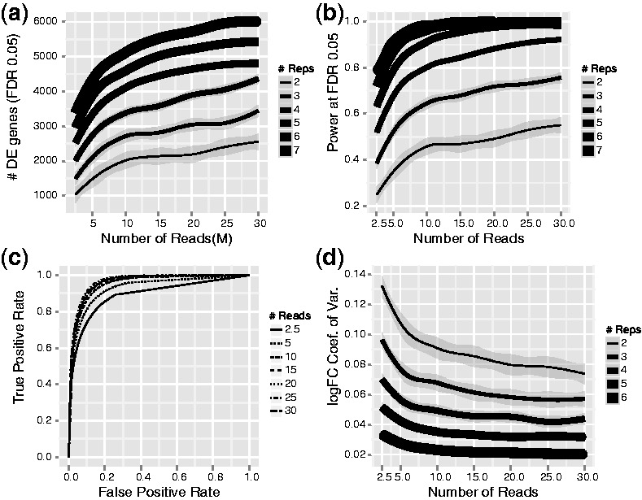

```
Liu et al. (2014) Bioinformatics
```

## Controlling batch effects

- Batch effects are sub-groups of measurements that have qualitatively different behavior across conditions and are unrelated to the biological or scientific variables in a study.
- Batch effects are problematic if they are confounded with the experimental variable.
- Batch effects that are randomly distributed across experimental variables can be controlled for.

## Controlling batch effects

[figure not shown]

## Controlling batch effects

[figure not shown]

## Controlling batch effects

- Batch effects are sub-groups of measurements that have qualitatively different behavior across conditions and are unrelated to the biological or scientific variables in a study.
- Batch effects are problematic if they are confounded with the experimental variable.
- Batch effects that are randomly distributed across experimental variables can be controlled for.
- Randomise all technical steps in data generation in order to avoid batch effects

## Controlling batch effects

- Batch effects are sub-groups of measurements that have qualitatively different behavior across conditions and are unrelated to the biological or scientific variables in a study.
- Batch effects are problematic if they are confounded with the experimental variable.
- Batch effects that are randomly distributed across experimental variables can be controlled for.
- Randomise all technical steps in data generation in order to avoid batch effects

[figure not shown]

## Controlling batch effects

- Batch effects are sub-groups of measurements that have qualitatively different behavior across conditions and are unrelated to the biological or scientific variables in a study.
- Batch effects are problematic if they are confounded with the experimental variable.
- Batch effects that are randomly distributed across experimental variables can be controlled for.
- Randomise all technical steps in data generation in order to avoid batch effects

[figure not shown]

## Controlling batch effects

- Batch effects are sub-groups of measurements that have qualitatively different behavior across conditions and are unrelated to the biological or scientific variables in a study.
- Batch effects are problematic if they are confounded with the experimental variable.
- Batch effects that are randomly distributed across experimental variables can be controlled for.
- Randomise all technical steps in data generation in order to avoid batch effects

[figure not shown]

## Alignment

[figure not shown]

- RNA does not contain the introns
- When aligning to the genome we need to use a splice-aware aligner and provide gene definitions (GTF) e.g.:
  - HISAT2 (uses Bowtie2)
  - Star
  - Or pseudoaligners e.g. Salmon or Kallisto

## Counting/Summarisation

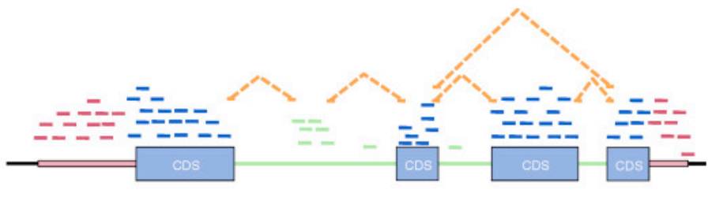

**Genome-based features**

- Exon or gene boundaries
- Isoform structures
- Gene multireads

**Transcript-based features**

- Transcript assembly
- Novel structures
- Isoform multireads

**HTSeq or Subread**

## Differential Gene Expression Analysis Workflow

[figure not shown]